# Analysis of weather impact on people and the economy

Alfonso R. Reyes

2017-02-11

## Questions

1. Across the United States, which types of events (as indicated in the EVTYPE variable) are most harmful with respect to population health?
2. Across the United States, which types of events have the greatest economic consequences?

## Synopsis

This report will perform an analysis on the National Oceanic Atmospheric Administration’s (NOAA) storm event database from 1950 to 2011 focusing on the weather impact on the population and the economy. We will download the dataset directly and then perform some clean up operations and filtering.

We will see the impact on the population: fatalities, injured, and the effect on the economy: property and crops. It does not take into account other effects such as defferred revenue, no income, future revenues, etc.

For the 1st question we will use these variables from the storm database: EVTYPE, FATALITIES and INJURIES. While for the 2nd question, we will use the variables: EVTYPE, PROPDMG, CROPDMG, PROPDMGEXP and CROPDMGEXP.

Other analysis can later be performed such as if the weather effects have been improving or worsening, what states have suffered the largest impact, what counties have the highest economic loss, etc.

## Data Processing

The data processing consists in the following steps:

```r
library(dplyr)
library(ggplot2)
library(gridExtra)
library(grid)
library(stringr)
library(rprojroot)
library(R.utils)
library(lubridate)
```

### Set up project folders with `rprojroot` package

```r
# package rprojroot required
root <- rprojroot::is_rstudio_project
root_file <- root$make_fix_file()
# root$find_file("REAME.md")
root_file()
cat("Setting up the project folders:\n")
project.data <- root_file("data")
project.extdata <- root_file("inst/extdata")
project.R <- root_file("R")

project.data
project.extdata
project.R
```

```
[1] "/home/superuser/git.projects/RR-PeerAsmnt2-NOAA_Storm"
Setting up the project folders:
[1] "/home/superuser/git.projects/RR-PeerAsmnt2-NOAA_Storm/data"
[1] "/home/superuser/git.projects/RR-PeerAsmnt2-NOAA_Storm/inst/extdata"
[1] "/home/superuser/git.projects/RR-PeerAsmnt2-NOAA_Storm/R"
```

### Downloading the data

We found a problem while trying to download the data file from the internet. The `bunzip2` format is not properly managed by the `download.file` function. So, we have to add a new function `bunzip2` from the package `R.utils` to download and unpack the compresed file. Of course, this could have been done by using the `read.csv` function to read the data file directly but that would be a “one-off” operation. To make the function `downloadZip` reusable for the future we used `bunzip2`. There is a flag in the function that allows the selection of that particular compression format.

```r
downloadZip <- function(fileUrl, outDir="./data", bzip2 = FALSE) {
  # function to download zipped and bunzip2 files and unpack
  temp <- tempfile()
  download.file(fileUrl, temp, mode = "wb")
  if (bzip2 == FALSE) {
    unzip(temp, exdir = outDir)
  }
  else {
    destfile <- paste(outDir, "dataset.csv", sep = "/")  # provide a filename
    bunzip2(temp, destname = destfile, overwrite = TRUE) # unpack bunzip2 file
  }
}
```

```r
# URL of the dataset file
fileUrl <- "https://d396qusza40orc.cloudfront.net/repdata%2Fdata%2FStormData.csv.bz2"
cat("Unpacking the raw data file:\n")
```

```
Unpacking the raw data file:
```

```r
outDir <- project.extdata             # folder for raw data
downloadZip(fileUrl, outDir = outDir, bzip2 = TRUE)   # download and unpack file
```

```r
# read the CSV file to memory
dataFile <- paste(project.extdata, "dataset.csv", sep = "/")
stormdata.raw <- read.csv(dataFile)
# stormdata <- stormdata.raw          # for the moment we will use a shorter name
```

### How our raw data look?

```r
# properties of the dataset
dims <- dim(stormdata.raw)
dims
```

```
[1] 902297     37
```

The names of the variables are:

```r
names(stormdata.raw)
```

```
 [1] "STATE__"    "BGN_DATE"   "BGN_TIME"   "TIME_ZONE"  "COUNTY"
 [6] "COUNTYNAME" "STATE"      "EVTYPE"     "BGN_RANGE"  "BGN_AZI"
[11] "BGN_LOCATI" "END_DATE"   "END_TIME"   "COUNTY_END" "COUNTYENDN"
[16] "END_RANGE"  "END_AZI"    "END_LOCATI" "LENGTH"     "WIDTH"
[21] "F"          "MAG"        "FATALITIES" "INJURIES"   "PROPDMG"
[26] "PROPDMGEXP" "CROPDMG"    "CROPDMGEXP" "WFO"        "STATEOFFIC"
[31] "ZONENAMES"  "LATITUDE"   "LONGITUDE"  "LATITUDE_E" "LONGITUDE_"
[36] "REMARKS"    "REFNUM"
```

This is how the raw data looks:

```r
as_data_frame(stormdata.raw)
```

```
# A tibble: 902,297 × 37
   STATE__           BGN_DATE BGN_TIME TIME_ZONE COUNTY COUNTYNAME  STATE
     <dbl>             <fctr>   <fctr>    <fctr>  <dbl>     <fctr> <fctr>
1        1  4/18/1950 0:00:00     0130       CST     97     MOBILE     AL
2        1  4/18/1950 0:00:00     0145       CST      3    BALDWIN     AL
3        1  2/20/1951 0:00:00     1600       CST     57    FAYETTE     AL
4        1   6/8/1951 0:00:00     0900       CST     89    MADISON     AL
5        1 11/15/1951 0:00:00     1500       CST     43    CULLMAN     AL
6        1 11/15/1951 0:00:00     2000       CST     77 LAUDERDALE     AL
7        1 11/16/1951 0:00:00     0100       CST      9     BLOUNT     AL
8        1  1/22/1952 0:00:00     0900       CST    123 TALLAPOOSA     AL
9        1  2/13/1952 0:00:00     2000       CST    125 TUSCALOOSA     AL
10       1  2/13/1952 0:00:00     2000       CST     57    FAYETTE     AL
# ... with 902,287 more rows, and 30 more variables: EVTYPE <fctr>,
#   BGN_RANGE <dbl>, BGN_AZI <fctr>, BGN_LOCATI <fctr>, END_DATE <fctr>,
#   END_TIME <fctr>, COUNTY_END <dbl>, COUNTYENDN <lgl>, END_RANGE <dbl>,
#   END_AZI <fctr>, END_LOCATI <fctr>, LENGTH <dbl>, WIDTH <dbl>, F <int>,
#   MAG <dbl>, FATALITIES <dbl>, INJURIES <dbl>, PROPDMG <dbl>,
#   PROPDMGEXP <fctr>, CROPDMG <dbl>, CROPDMGEXP <fctr>, WFO <fctr>,
#   STATEOFFIC <fctr>, ZONENAMES <fctr>, LATITUDE <dbl>, LONGITUDE <dbl>,
#   LATITUDE_E <dbl>, LONGITUDE_ <dbl>, REMARKS <fctr>, REFNUM <dbl>
```

### What variables do we keep for our analysis?

These are the variables that we consider important for the analysis:

```
    REFNUM, BGN_DATE, STATE, COUNTY, COUNTYNAME, EVTYPE,
    FATALITIES, INJURIES, PROPDMG, PROPDMGEXP, CROPDMG, CROPDMGEXP, REMARKS
```

### Clean up the dataset

We will transform the variable `BGN_DATE` from a factor to a date variable. We will later use it for our summaries. We will also take out some variables that are not relevant to our study.

```r
# read the raw data from original source and load to object stormdata
# stormdata will be cleaned up, some variables converted and some corrections made.
stormdata <- stormdata.raw %>%
  select(REFNUM, BGN_DATE, STATE, COUNTY, COUNTYNAME, EVTYPE,
         FATALITIES, INJURIES, PROPDMG, PROPDMGEXP, CROPDMG, CROPDMGEXP, REMARKS) %>%
  # convert BGN_DATE to date format
  mutate(DATE = mdy_hms(as.character(BGN_DATE))) %>%    # convert to date
  select(REFNUM, DATE, STATE, COUNTY, COUNTYNAME, EVTYPE,
         FATALITIES, INJURIES, PROPDMG, PROPDMGEXP, CROPDMG, CROPDMGEXP, REMARKS) %>%
  # convert *EXP to uppercase and remove trailing spaces
  mutate(PROPDMGEXP = as.factor(toupper(str_trim(PROPDMGEXP))),      # clean the string
         CROPDMGEXP = as.factor(toupper(str_trim(CROPDMGEXP)))) %>%
  mutate(REMARKS = as.character(REMARKS))

# rm(stormdata.raw)     # release big dataset
# save(stormdata, file = paste(project.data, "stormdata.rda", sep = "/"))
```

### IMPORTANT

There is a typo in one of the observations in the California flood 2005/2006 that distorts the economy impact. The typo says **billions** instead of **millions** in the flood events in Californa. We noticed this while plotting the economic impact of the weather events. This code below will filter the event that started on Christmas 2005 and persisted during 2006 New Year.

We are saving the corrections in `stormdata.rda`. So, if the reader wants to reproduce the error, it wil be necessary to load the data from scratch, starting with downloading the file from the original source in the web. The code above wll reproduce the steps necessary. To see the observation with the typo (it was writen “B” instead of “M” in the variable `PROPDMGEXP`), it corresponds to observation 605943 as identified by the variable `REFNUM`.

```r
# floods in California from Xmas 2005 to around New Year 2006
# one record improperly entered as Billions instead of millions REFNUM=605943
ca.flood <- stormdata %>%
  filter(DATE >= "2005-12-25" & DATE <= "2006-01-02" & STATE == "CA" & PROPDMG > 0) %>%
  arrange(DATE) %>%
  select(REFNUM, DATE, STATE, PROPDMG, PROPDMGEXP, CROPDMG, CROPDMGEXP, REMARKS)

as_data_frame(ca.flood)
```

```
# A tibble: 59 × 8
   REFNUM       DATE  STATE PROPDMG PROPDMGEXP CROPDMG CROPDMGEXP
    <dbl>     <dttm> <fctr>   <dbl>     <fctr>   <dbl>     <fctr>
1  567175 2005-12-26     CA    20.0          K       0
2  567179 2005-12-28     CA    55.9          M       0
3  567180 2005-12-28     CA    10.0          K       0
4  567184 2005-12-29     CA    60.8          M       8          M
5  567185 2005-12-29     CA     5.0          K       0
6  567186 2005-12-30     CA     5.0          K       0
7  567187 2005-12-30     CA     5.0          K       0
8  567193 2005-12-30     CA     1.0          M       0
9  567197 2005-12-31     CA     1.0          M       0
10 567198 2005-12-31     CA     1.0          M       0
# ... with 49 more rows, and 1 more variables: REMARKS <chr>
```

The event occurring in January 2006 (id=605943) has been improperly recorded as economic losses of 150 Billion US dollars. After some research we found that the numbers are more in the hundred million dollars range. See paper USGS Open-File Report 2006–1182, which describes the phenomena and economic losses.

### Making the correction from Billions to Millions

Replace the “B” of billions by “M” (millons):

```r
stormdata[stormdata$REFNUM==605943, c("PROPDMGEXP")] <- "M"
stormdata[stormdata$REFNUM==605943, c("PROPDMGEXP")]
```

```
[1] M
Levels:  - ? + 0 1 2 3 4 5 6 7 8 B H K M
```

Add a new comment on correction to the `REMARKS` variable:

```r
# Get the remark if stormdata.raw was loaded
remarks.605943 <- stormdata[stormdata$REFNUM==605943, c("REMARKS")]
remarks.605943
```

```
[1] "Major flooding continued into the early hours of January 1st, before the Napa River finally fell below flood stage and the water receeded. Flooding was severe in Downtown Napa from the Napa Creek and the City and Parks Department was hit with $6 million in damage alone. The City of Napa had 600…
```

```r
text.was <- "Major flooding continued into the early hours of January 1st, before the Napa River finally fell below flood stage and the water receeded. Flooding was severe in Downtown Napa from the Napa Creek and the City and Parks Department was hit with $6 million in damage alone. The City of Napa had 600 homes with moderate damage, 150 damaged businesses with costs of at least $70 million."

# this is the new remark
remarks.605943 <- paste("Correct typo in property damage from 'B' (biilion) to 'M' (million).", text.was, sep = "| ")

# impute the new remark
stormdata[stormdata$REFNUM==605943, c("REMARKS")] <- remarks.605943
```

This is a view of the data frame that we will use in our analysis.

```r
# save stormdata after corrections
save(stormdata, file = paste(project.data, "stormdata.rda", sep = "/"))
# remove data frame from memory
rm(stormdata)
# load data frame
load(paste(project.data, "stormdata.rda", sep = "/"))
# show on screen
as_data_frame(stormdata)
```

```
# A tibble: 902,297 × 13
   REFNUM       DATE  STATE COUNTY COUNTYNAME  EVTYPE FATALITIES INJURIES
    <dbl>     <dttm> <fctr>  <dbl>     <fctr>  <fctr>      <dbl>    <dbl>
1       1 1950-04-18     AL     97     MOBILE TORNADO          0       15
2       2 1950-04-18     AL      3    BALDWIN TORNADO          0        0
3       3 1951-02-20     AL     57    FAYETTE TORNADO          0        2
4       4 1951-06-08     AL     89    MADISON TORNADO          0        2
5       5 1951-11-15     AL     43    CULLMAN TORNADO          0        2
6       6 1951-11-15     AL     77 LAUDERDALE TORNADO          0        6
7       7 1951-11-16     AL      9     BLOUNT TORNADO          0        1
8       8 1952-01-22     AL    123 TALLAPOOSA TORNADO          0        0
9       9 1952-02-13     AL    125 TUSCALOOSA TORNADO          1       14
10     10 1952-02-13     AL     57    FAYETTE TORNADO          0        0
# ... with 902,287 more rows, and 5 more variables: PROPDMG <dbl>,
#   PROPDMGEXP <fctr>, CROPDMG <dbl>, CROPDMGEXP <fctr>, REMARKS <chr>
```

## The 1st Question. Which types of events are most harmful with respect to population health?

### Create data frames for 1st question

We want to find now which type of events is more harmful to population health. We could group by `EVTYPE` and showing the variables FATALITIES and INJURIES.

```r
# byEvent.0: dataset where main sort criteria is FATALITIES
byEvent.0 <- stormdata %>%
  select(EVTYPE, FATALITIES, INJURIES) %>%
  group_by(EVTYPE) %>%
  summarize(fatal.sum = sum(FATALITIES), injur.sum = sum(INJURIES)) %>%
  arrange(desc(fatal.sum), desc(injur.sum))

byEvent.0
```

```
# A tibble: 985 × 3
           EVTYPE fatal.sum injur.sum
           <fctr>     <dbl>     <dbl>
1         TORNADO      5633     91346
2  EXCESSIVE HEAT      1903      6525
3     FLASH FLOOD       978      1777
4            HEAT       937      2100
5       LIGHTNING       816      5230
6       TSTM WIND       504      6957
7           FLOOD       470      6789
8     RIP CURRENT       368       232
9       HIGH WIND       248      1137
10      AVALANCHE       224       170
# ... with 975 more rows
```

```r
# byEvent.1: dataset where the main sort criteria is INJURIES
byEvent.1 <- stormdata %>%
  select(EVTYPE, FATALITIES, INJURIES) %>%
  group_by(EVTYPE) %>%
  summarize(injur.sum = sum(INJURIES), fatal.sum = sum(FATALITIES)) %>%
  arrange(desc(injur.sum), desc(fatal.sum))

byEvent.1
```

```
# A tibble: 985 × 3
              EVTYPE injur.sum fatal.sum
              <fctr>     <dbl>     <dbl>
1            TORNADO     91346      5633
2          TSTM WIND      6957       504
3              FLOOD      6789       470
4     EXCESSIVE HEAT      6525      1903
5          LIGHTNING      5230       816
6               HEAT      2100       937
7          ICE STORM      1975        89
8        FLASH FLOOD      1777       978
9  THUNDERSTORM WIND      1488       133
10              HAIL      1361        15
# ... with 975 more rows
```

### Plots that address the 1st question

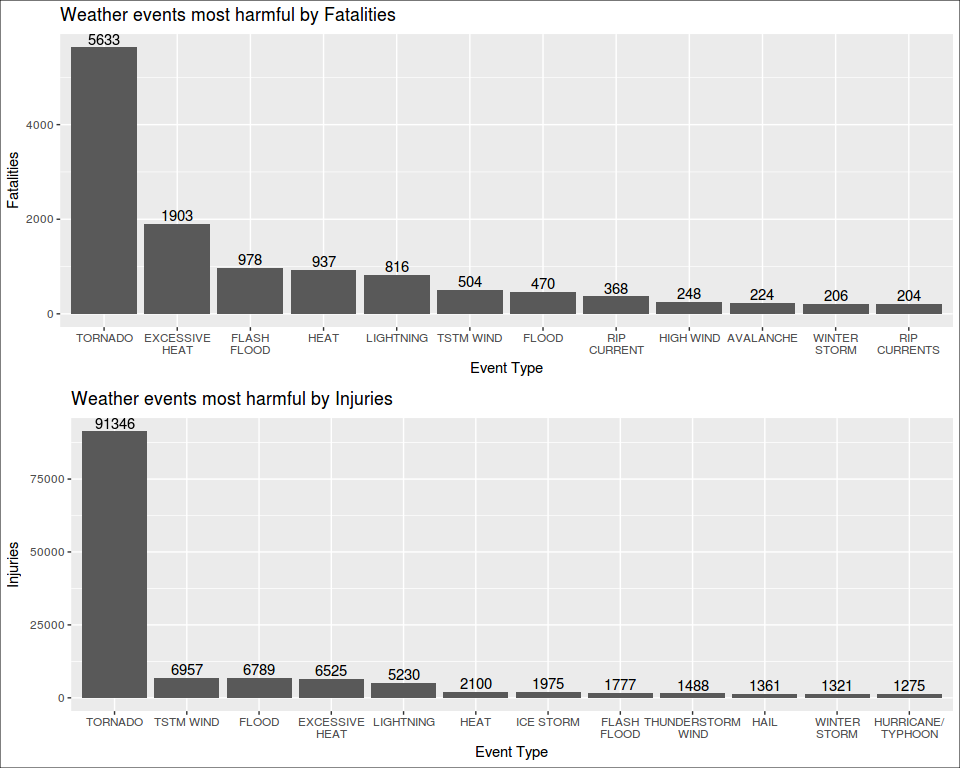

```r
byEvent.Fat <- byEvent.0[1:12, ]
byEvent.Inj <- byEvent.1[1:12, ]

# plot sorted by number of fatalities
p1 <- ggplot(byEvent.Fat, aes(x = reorder(EVTYPE, -fatal.sum), y = fatal.sum)) +
  geom_bar(stat = "identity") +
  xlab("Event Type") + ylab("Fatalities") +
  geom_text(aes(label=fatal.sum, vjust = -0.25)) +
  scale_x_discrete(labels = function(EVTYPE) str_wrap(EVTYPE, width = 10)) +
  ggtitle("Weather events most harmful by Fatalities")

# plot sorted by number of injuries
p2 <- ggplot(byEvent.Inj, aes(x = reorder(EVTYPE, -injur.sum), y = injur.sum)) +
  geom_bar(stat = "identity") +
  xlab("Event Type") + ylab("Injuries") +
  geom_text(aes(label=injur.sum, vjust = -0.25)) +
  scale_x_discrete(labels = function(EVTYPE) str_wrap(EVTYPE, width = 10)) +
  ggtitle("Weather events most harmful by Injuries")

gridExtra::grid.arrange(p1, p2)
grid.rect(gp=gpar(fill=NA))
```

Tornados, Excessive heat, flash floods, heat and lightning are the weather events most harmful to the population accross the United States.

## The 2nd Question. Which types of events have the greatest economic consequences?

## Assessing the Economic Damage

The property and crop damage are not in a unique monetary units; they use thousands, millions and billions. They are specified in the variables `PROPDMGEXP` and `CROPDMGEXP`. In addition, other characters are used under these variables. In the *Appendix* is explained how many more identifiers are used as a monetary identifier.

We will start by converting the monetary damages to a consistent units. We will choose thousands.

```r
byDamage <- stormdata %>%
  select(EVTYPE, PROPDMG, PROPDMGEXP, CROPDMG, CROPDMGEXP) %>%
  group_by(EVTYPE) %>%
  # convert to unique dollar multiplier
  mutate(PROPDMG.K = ifelse(PROPDMGEXP == "K", PROPDMG * 1,
                     ifelse(PROPDMGEXP == "M", PROPDMG * 1000,
                     ifelse(PROPDMGEXP == "B", PROPDMG * 1E6, 0)))) %>%
  mutate(CROPDMG.K = ifelse(CROPDMGEXP == "K", CROPDMG * 1,
                     ifelse(CROPDMGEXP == "M", CROPDMG * 1000,
                     ifelse(CROPDMGEXP == "B", CROPDMG * 1E6, 0))))
byDamage
```

```
Source: local data frame [902,297 x 7]
Groups: EVTYPE [985]

    EVTYPE PROPDMG PROPDMGEXP CROPDMG CROPDMGEXP PROPDMG.K CROPDMG.K
    <fctr>   <dbl>     <fctr>   <dbl>     <fctr>     <dbl>     <dbl>
1  TORNADO    25.0          K       0                 25.0         0
2  TORNADO     2.5          K       0                  2.5         0
3  TORNADO    25.0          K       0                 25.0         0
4  TORNADO     2.5          K       0                  2.5         0
5  TORNADO     2.5          K       0                  2.5         0
6  TORNADO     2.5          K       0                  2.5         0
7  TORNADO     2.5          K       0                  2.5         0
8  TORNADO     2.5          K       0                  2.5         0
9  TORNADO    25.0          K       0                 25.0         0
10 TORNADO    25.0          K       0                 25.0         0
# ... with 902,287 more rows
```

We convert the thousands to millions of US$ and only one variable, the total economic damage.

```r
byDamage.mm <- byDamage %>%
  summarize(propdmg.k = sum(PROPDMG.K), cropdmg.k = sum(CROPDMG.K)) %>%
  mutate(propdmg.m = propdmg.k / 1000, cropdmg.m = cropdmg.k / 1000) %>%
  select(EVTYPE, propdmg.m, cropdmg.m) %>%
  mutate(totaldmg.mm = propdmg.m + cropdmg.m) %>%
  mutate(totaldmg.bi = totaldmg.mm / 1000) %>%
  # arrange(desc(propdmg.m), desc(cropdmg.m))
  arrange(desc(totaldmg.mm))

byDamage.mm
```

```
# A tibble: 985 × 5
              EVTYPE propdmg.m  cropdmg.m totaldmg.mm totaldmg.bi
              <fctr>     <dbl>      <dbl>       <dbl>       <dbl>
1  HURRICANE/TYPHOON 69305.840  2607.8728   71913.713   71.913713
2            TORNADO 56937.160   414.9531   57352.114   57.352114
3        STORM SURGE 43323.536     0.0050   43323.541   43.323541
4              FLOOD 29772.710  5661.9685   35434.678   35.434678
5               HAIL 15732.267  3025.9545   18758.221   18.758221
6        FLASH FLOOD 16140.812  1421.3171   17562.129   17.562129
7            DROUGHT  1046.106 13972.5660   15018.672   15.018672
8          HURRICANE 11868.319  2741.9100   14610.229   14.610229
9        RIVER FLOOD  5118.945  5029.4590   10148.405   10.148404
10         ICE STORM  3944.928  5022.1135    8967.041    8.967041
# ... with 975 more rows
```

### Plots for the 2nd question

```r
byDamage.mm.top5 <- byDamage.mm[1:10, ]
byDamage.mm.top5
```

```
# A tibble: 10 × 5
              EVTYPE propdmg.m  cropdmg.m totaldmg.mm totaldmg.bi
              <fctr>     <dbl>      <dbl>       <dbl>       <dbl>
1  HURRICANE/TYPHOON 69305.840  2607.8728   71913.713   71.913713
2            TORNADO 56937.160   414.9531   57352.114   57.352114
3        STORM SURGE 43323.536     0.0050   43323.541   43.323541
4              FLOOD 29772.710  5661.9685   35434.678   35.434678
5               HAIL 15732.267  3025.9545   18758.221   18.758221
6        FLASH FLOOD 16140.812  1421.3171   17562.129   17.562129
7            DROUGHT  1046.106 13972.5660   15018.672   15.018672
8          HURRICANE 11868.319  2741.9100   14610.229   14.610229
9        RIVER FLOOD  5118.945  5029.4590   10148.405   10.148404
10         ICE STORM  3944.928  5022.1135    8967.041    8.967041
```

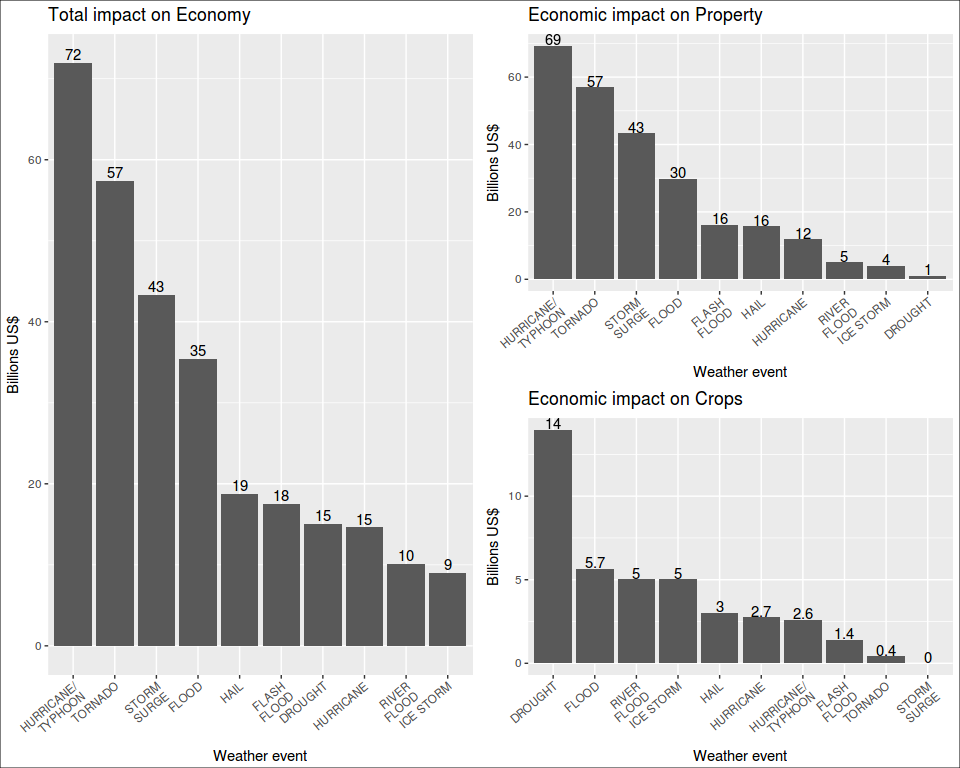

```r
# plots for total economic losses
r1 <- ggplot(byDamage.mm.top5, aes(x = reorder(EVTYPE, -totaldmg.bi), y = totaldmg.bi)) +
  geom_bar(stat = "identity") +
  labs(y = "Billions US$", x = "Weather event") +
  ggtitle("Total impact on Economy") +
  geom_text(aes(label=round(totaldmg.bi, 0), vjust = -0.25)) +
  theme(axis.text.x = element_text(angle = 40, hjust = 1)) +
  scale_x_discrete(labels = function(EVTYPE) str_wrap(EVTYPE, width = 10))

# plot for impact on property
propdmg.bi <- byDamage.mm.top5$propdmg.m/1000
r2 <- ggplot(byDamage.mm.top5, aes(x = reorder(EVTYPE, -propdmg.bi), y = propdmg.bi)) +
  geom_bar(stat = "identity") +
  labs(y = "Billions US$", x = "Weather event") +
  ggtitle("Economic impact on Property") +
  geom_text(aes(label=round(propdmg.bi, 0), vjust = -0.05)) +
  theme(axis.text.x = element_text(angle = 40, hjust = 1)) +
  scale_x_discrete(labels = function(EVTYPE) str_wrap(EVTYPE, width = 10))

# plot for impact on crops
cropdmg.bi <- byDamage.mm.top5$cropdmg.m/1000
r3 <- ggplot(byDamage.mm.top5, aes(x = reorder(EVTYPE, -cropdmg.bi), y = cropdmg.bi)) +
  geom_bar(stat = "identity") +
  labs(y = "Billions US$", x = "Weather event") +
  ggtitle("Economic impact on Crops") +
  geom_text(aes(label=round(cropdmg.bi, 1), vjust = -0.05)) +
  theme(axis.text.x = element_text(angle = 40, hjust = 1)) +
  scale_x_discrete(labels = function(EVTYPE) str_wrap(EVTYPE, width = 10))

gridExtra::grid.arrange(r1, arrangeGrob(r2, r3), ncol=2)  # 3-in-1 figure
grid.rect(gp=gpar(fill=NA))
```

## Appendix

### Have the number of fatalities and injuries increased over the years?

We have generated a couple of datasets that are much smaller in size than the original dataset.

- byYearEvent: is a dataset that contains a summary of the events, fatalities, injuries, economic losses in property and crops in millions of US$.
- byYearSummary: a dataset showing the year and the wather impact on life and the economy. Four variables: year, fatalities, injured and economy losses in millions of USD.

```r
# By year, by event
byYearEvent <- stormdata %>%
  group_by(DATE, EVTYPE) %>%
  mutate(PROPDMG.K = ifelse(PROPDMGEXP == "K", PROPDMG * 1,
                     ifelse(PROPDMGEXP == "M", PROPDMG * 1000,
                     ifelse(PROPDMGEXP == "B", PROPDMG * 1E6, 0)))) %>%
  mutate(CROPDMG.K = ifelse(CROPDMGEXP == "K", CROPDMG * 1,
                     ifelse(CROPDMGEXP == "M", CROPDMG * 1000,
                     ifelse(CROPDMGEXP == "B", CROPDMG * 1E6, 0)))) %>%
  summarize(fatalities = sum(FATALITIES),
            injuries   = sum(INJURIES),
            propdmg.M  = sum(PROPDMG.K) / 1000,
            cropdmg.M  = sum(CROPDMG.K) /1000
            )
# save unique events by year
save(byYearEvent, file = paste(project.data, "byYearEvent.rda", sep = "/"))

byYearEvent
```

```
Source: local data frame [83,144 x 6]
Groups: DATE [?]

         DATE  EVTYPE fatalities injuries propdmg.M cropdmg.M
       <dttm>  <fctr>      <dbl>    <dbl>     <dbl>     <dbl>
1  1950-01-03 TORNADO          0        7    3.0250         0
2  1950-01-13 TORNADO          1        1    0.0025         0
3  1950-01-25 TORNADO          0        5    0.5000         0
4  1950-01-26 TORNADO          0        2    0.0000         0
5  1950-02-11 TORNADO          1       23    0.5500         0
6  1950-02-12 TORNADO         35      169    3.1525         0
7  1950-02-13 TORNADO          9        9    0.0275         0
8  1950-02-27 TORNADO          0        0    0.0250         0
9  1950-03-01 TORNADO          0        0    0.0000         0
10 1950-03-16 TORNADO          0        0    0.0025         0
# ... with 83,134 more rows
```

```r
#load(paste(project.data, "byYearEvent.rda", sep = "/"))  # load the data

byYearSummary <- byYearEvent %>%
  mutate(year = year(DATE)) %>%           # get only the year
  group_by(year) %>%                      # group by year
  summarize(fatalities = sum(fatalities), # calculate total fatalities and injuries
            injuries = sum(injuries),
            damage.mm = round(sum(propdmg.M) + sum(cropdmg.M), 0), # total in millions
            damage.bb = round(damage.mm / 1000, 2)) %>%       # total damage in billions
  arrange(desc(damage.bb))

# save losses by year
save(byYearSummary, file = paste(project.data,
                                 "byYearSummary.rda",
                                 sep = "/"))
byYearSummary
```

```
# A tibble: 62 × 5
    year fatalities injuries damage.mm damage.bb
   <dbl>      <dbl>    <dbl>     <dbl>     <dbl>
1   2005        469     1834    100825    100.83
2   2004        370     2426     26799     26.80
3   1993        298     2149     21987     21.99
4   2011       1002     7792     21556     21.56
5   2008        488     2703     17778     17.78
6   1998        687    11177     16111     16.11
7   1995       1491     4480     12733     12.73
8   1999        908     5148     12254     12.25
9   2001        469     2721     11844     11.84
10  2003        443     2931     11398     11.40
# ... with 52 more rows
```

Years with the most economic damage:

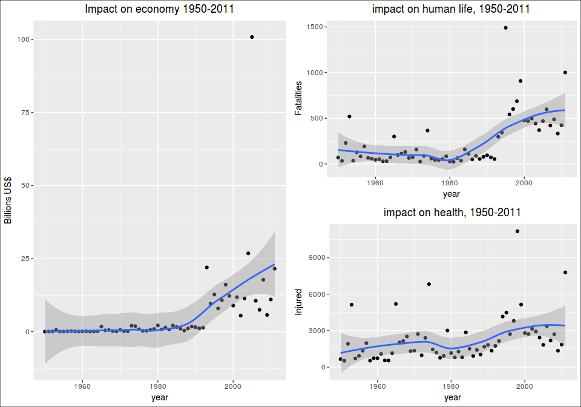

```r
# load data frame
load(paste(project.data, "byYearSummary.rda", sep = "/"))

q1 <- ggplot(byYearSummary, aes(x = year, y = damage.bb)) +
  geom_point() +
  geom_smooth() +
  ggtitle("Impact on economy 1950-2011") +
  labs(y = "Billions US$") +
  theme(plot.title = element_text(hjust=0.5))

q2 <- ggplot(byYearSummary, aes(x = year, y = fatalities)) +
  geom_point() +
  geom_smooth() +
  ggtitle("impact on human life, 1950-2011") +
  labs(y = "Fatalities") +
    theme(plot.title = element_text(hjust=0.5))

q3 <- ggplot(byYearSummary, aes(x = year, y = injuries)) +
  geom_point() +
  geom_smooth() +
  ggtitle("impact on health, 1950-2011") +
  labs(y = "Injured") +
    theme(plot.title = element_text(hjust=0.5))


gridExtra::grid.arrange(q1, arrangeGrob(q2, q3), ncol=2)
grid.rect(gp=gpar(fill=NA))
```

```r
# load small data frame
load(paste(project.data, "stormdata.small.rda", sep = "/"))

# what is the worst weather event in 2005?
worst <- stormdata.small %>%
  select(REFNUM, DATE, STATE, EVTYPE, PROPDMG, PROPDMGEXP) %>%
  arrange(desc(PROPDMG))

as_data_frame(worst)
```

```
# A tibble: 902,297 × 6
   REFNUM       DATE  STATE            EVTYPE PROPDMG PROPDMGEXP
    <dbl>     <dttm> <fctr>            <fctr>   <dbl>     <fctr>
1  778558 2009-07-26     NC THUNDERSTORM WIND    5000          K
2  808182 2010-05-13     IL       FLASH FLOOD    5000          K
3  808183 2010-05-13     IL       FLASH FLOOD    5000          K
4  900646 2011-10-29     AM        WATERSPOUT    5000          K
5  791393 2009-12-25     PR         LANDSLIDE    4800          K
6  750915 2009-03-28     TN           TORNADO    4410          K
7  762379 2009-05-12     OK THUNDERSTORM WIND    3500          K
8  815064 2010-06-24     CT THUNDERSTORM WIND    3200          K
9  749008 2009-02-11     IL         HIGH WIND    3000          K
10 755010 2009-04-29     IN             FLOOD    3000          K
# ... with 902,287 more rows
```

### Unknown identifiers for monetary units

There are some unspecified units in `PROPDMGEXP` and `CROPDMGEXP`. There is no a reasonable way to determine the units or damage value from the remarks. Sometimes is thousands or in 10K, or other.

In two cases, we found that instead of “M” for millions the lowercase version of it “m” was used. We converted them to uppercase before summarizing the data. Other characters or digits did not bring a special meaning to the dollar amount, so we didn’t convert them even thoiugh we read the remarks to find some relationship.

Show some events with doubtful monetary units.

```r
events <- stormdata %>%
  select(REFNUM, DATE, EVTYPE, REMARKS) %>%
  filter(REFNUM %in% c(605943, 577616, 577615, 581535))
as_data_frame(events)
```

```
# A tibble: 4 × 4
  REFNUM       DATE            EVTYPE
   <dbl>     <dttm>            <fctr>
1 577615 2005-08-28 HURRICANE/TYPHOON
2 577616 2005-08-29       STORM SURGE
3 581535 2005-08-29       STORM SURGE
4 605943 2006-01-01             FLOOD
# ... with 1 more variables: REMARKS <chr>
```

```r
unique(byDamage$PROPDMGEXP)
```

```
 [1] K M   B + 0 5 6 ? 4 2 3 H 7 - 1 8
Levels:  - ? + 0 1 2 3 4 5 6 7 8 B H K M
```

```r
unique(byDamage$CROPDMGEXP)
```

```
[1]   M K B ? 0 2
Levels:  ? 0 2 B K M
```

```r
summary(byDamage)
```

```
               EVTYPE          PROPDMG          PROPDMGEXP
 HAIL             :288661   Min.   :   0.00          :465934
 TSTM WIND        :219940   1st Qu.:   0.00   K      :424665
 THUNDERSTORM WIND: 82563   Median :   0.00   M      : 11338
 TORNADO          : 60652   Mean   :  12.06   0      :   216
 FLASH FLOOD      : 54277   3rd Qu.:   0.50   B      :    39
 FLOOD            : 25326   Max.   :5000.00   5      :    28
 (Other)          :170878                     (Other):    77
    CROPDMG        CROPDMGEXP   PROPDMG.K          CROPDMG.K
 Min.   :  0.000    :618413   Min.   :       0   Min.   :      0
 1st Qu.:  0.000   ?:     7   1st Qu.:       0   1st Qu.:      0
 Median :  0.000   0:    19   Median :       0   Median :      0
 Mean   :  1.527   2:     1   Mean   :     346   Mean   :     54
 3rd Qu.:  0.000   B:     9   3rd Qu.:       0   3rd Qu.:      0
 Max.   :990.000   K:281853   Max.   :31300000   Max.   :5000000
                   M:  1995
```

Here is how we know how many observations do not carry the “K”, “M” and “B” identifiers.

```r
unknown <- stormdata %>%
  select(STATE, EVTYPE, PROPDMGEXP, CROPDMGEXP, REMARKS) %>%
  filter(!toupper(PROPDMGEXP) %in% c("K", "M", "B") | !toupper(CROPDMGEXP) %in% c("K", "M", "B"))
```

There are 622760 observations which dollar amount units are not properly identified in `PROPDMGEXP` and `CROPDMGEXP` variables.

### The observation ID

We have observation IDs in the variable `REFNUM`. We check if all its values are unique:

```r
# REFNUM is the record id of the observation and is unique.
length(unique(stormdata$REFNUM))
range(unique(stormdata$REFNUM))
```

```
[1] 902297
[1]      1 902297
```

### The recorded weather events

Event Types `EVTYPE`

```r
# want to know how many levels this factor has
as_data_frame(unique(stormdata$EVTYPE), 10)
```

```
# A tibble: 985 × 1
                       value
                      <fctr>
1                    TORNADO
2                  TSTM WIND
3                       HAIL
4              FREEZING RAIN
5                       SNOW
6      ICE STORM/FLASH FLOOD
7                   SNOW/ICE
8               WINTER STORM
9  HURRICANE OPAL/HIGH WINDS
10        THUNDERSTORM WINDS
# ... with 975 more rows
```

There are 985 different type of events.

### Saving a smaller dataset without the remarks

Create a small data frame without the `REMARKS` variable.

```r
stormdata.small <- stormdata %>%
  select(REFNUM, DATE, STATE, COUNTY, COUNTYNAME, EVTYPE,     # reorder
         FATALITIES, INJURIES, PROPDMG, PROPDMGEXP, CROPDMG, CROPDMGEXP)

as_data_frame(stormdata.small)
```

```
# A tibble: 902,297 × 12
   REFNUM       DATE  STATE COUNTY COUNTYNAME  EVTYPE FATALITIES INJURIES
    <dbl>     <dttm> <fctr>  <dbl>     <fctr>  <fctr>      <dbl>    <dbl>
1       1 1950-04-18     AL     97     MOBILE TORNADO          0       15
2       2 1950-04-18     AL      3    BALDWIN TORNADO          0        0
3       3 1951-02-20     AL     57    FAYETTE TORNADO          0        2
4       4 1951-06-08     AL     89    MADISON TORNADO          0        2
5       5 1951-11-15     AL     43    CULLMAN TORNADO          0        2
6       6 1951-11-15     AL     77 LAUDERDALE TORNADO          0        6
7       7 1951-11-16     AL      9     BLOUNT TORNADO          0        1
8       8 1952-01-22     AL    123 TALLAPOOSA TORNADO          0        0
9       9 1952-02-13     AL    125 TUSCALOOSA TORNADO          1       14
10     10 1952-02-13     AL     57    FAYETTE TORNADO          0        0
# ... with 902,287 more rows, and 4 more variables: PROPDMG <dbl>,
#   PROPDMGEXP <fctr>, CROPDMG <dbl>, CROPDMGEXP <fctr>
```

If we save the data frame `stormdata` as an .rda file the size is 46 megabytes. On the other hand, if we omit the `REMARKS` variable, the new dataset shrinks to only 4.6 megabytes. We will take this route of saving the smaller file as well.

```r
# save unique events by year
save(stormdata.small, file = paste(project.data, "stormdata.small.rda", sep = "/"))
```